# Introduction to R and RStudio

# Instructions

When you download this file, make sure you save it in your ResearchInLinguistics R project folder, which contains the folder ‘data’ with all your data. Otherwise the code won’t run properly (because it won’t be able to find your data in the data folder).

# About RStudio

We went over the layout of RStudio. There are four main panels when you open up R Studio.

1. In the top left, is the panel with your **.Rmd document** (like this document). This is where you write your R code that you want to save.
2. Next to that in the top right is the **Environment** panel, this is where you can see all your variables (including datasets that you have loaded), so you can keep track of them and remember what you called them (shown in the left column) and what they contain (shown in the right column).
3. In the bottom left is the **Console**, this is where you can type any R commands that you don’t need to be saved. For example, you can use it to install packages (since you only need to do this once), or to test out functions to see what they do.
4. In the bottom right is your **Files pane**, this shows you what files you have in your working directory. You can use it to check, for example, what your data files are called and where they are stored when you read them into R.

# About .Rmd documents

This document is an .Rmd = R Markdown document. These are the types of documents we will be using throughout the course. An R markdown document has three main componenets:

1. R code
2. *Markdown* text
3. YAML header

## R code chunks

R code is written in *chunks*. To insert a chunk into your .Rmd document, type ctrl + alt + I on Windows, or command + option + I on mac.

The chunk below prints a message “This is an R chunk”.

There are two ways to run code in R chunks:

1. Click on the green arrow (looks like a play sign) in the top right of the chunk. This runs all the code in the chunk.
2. Place your cursor in the line of code you want to run, and press ctrl + enter (or command + enter for macs). This will run just that line of code that you’ve selected. If you want to run multiple lines (but not all the code in the chunk), then select all the lines you want to run then press ctrl + enter (/command + enter)

```r
print("This is an R chunk")
```

```
[1] "This is an R chunk"
```

## Markdown text

Markdown is a special way of writing *plain text* (remember, plain text is good for research because it is readable by any computer/person anywhere) in a way that also includes some basic formatting, e.g. headers, italic and bold font, lists, etc.

This is how we write different things in Markdown:

```
# Heading
## Sub-heading
### Sub-sub heading

*italic*
**bold**

- bullet point
- bullet point
    - sub point

* bullet point
* bullet point
   - sub point

[click here](www.mywebsite.com)

![an image](https://addresstoanimage/image.jpg){width=50%}
```

The width variable for images is if you want to make them smaller or larger.

In your R notebook, it will just look like this, but then when you press the button at the top that says ‘Preview’, it will make a html document for you with the proper formatting, which will look like this:

# Heading

## Subheading

### Sub-sub heading

*italic* **bold**

- bullet point
- bullet point
  - sub point
- bullet point
- bullet point
  - sub point

click here

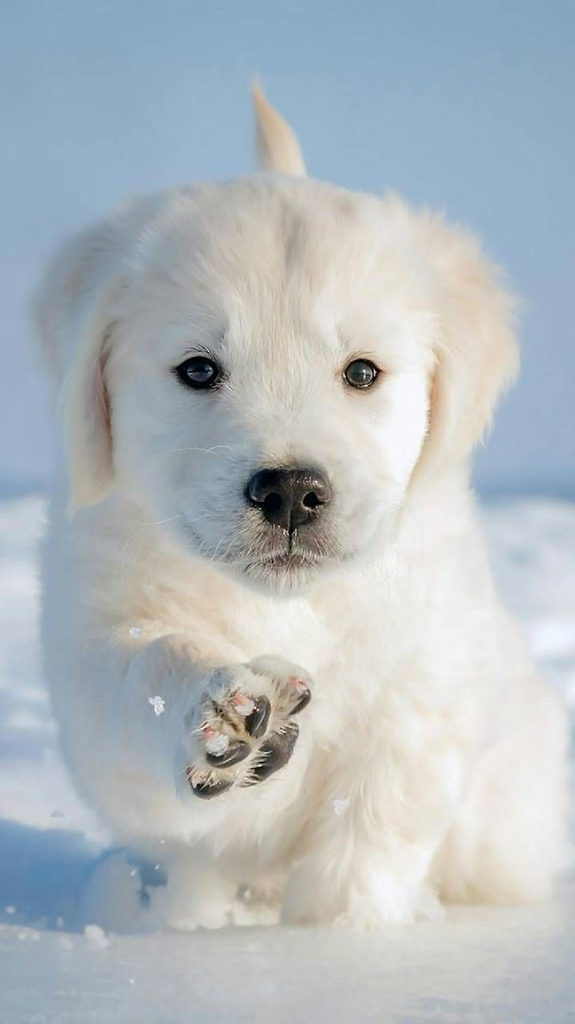

an image

If you want to know more, you can read the [markdown bible](https://bookdown.org/yihui/rmarkdown/) or look at the [cheatsheet](https://github.com/rstudio/cheatsheets/raw/master/rmarkdown-2.0.pdf). The cheatsheet and a link to the markdown bible are also in studium, under the ‘Cheatsheets’ section in the Modules page.

## YAML Header

The YAML header is the thing at the top of the .Rmd document that looks like this:

```
---
title: "Introduction to R and RStudio"
output: html_notebook
---
```

YAML stands for “YAML Ain’t Markup Language”. The three dashes (—) at the start and end of the YAML distinguish it as separate from both your markdown and your code chunks.

The YAML tells R what kind of output document(s) to make from your .Rmd document.

In this course, we will be using html notebooks as our main output format.

To generate the notebook, click on the button at the top of the .Rmd document that says ‘Preview’.

The html document will open in a new window. You will also see a .html file with the same name as your .Rmd file saved next to it in the folder where you have your .Rmd document.

## Other formats

If you click on the arrow next to the preview button, you can see that there are other output options as well. You can also change the type of output by editing the YAML directly. Below are some possible options:

```
output: html_document
output: word_document
output: pdf_document
output: slidy_presentation
output: html_notebook
```

A `slidy_presentation` is a html slideshow (the slides I used in the first lecture were made by setting the output of the markdown document to `slidy_presentation`).

Note that to make a PDF document, you will need to have a version of LaTex installed. If you use Windows, [MikTex](https://miktex.org/download) will install a basic LaTex system. If you use mac, you can install [MacTex](https://tug.org/mactex/).

## Previewing versus Knitting

Notice that while for the `html_notebook` we ‘Preview’ the notebook when generating output, but for the other formats with ‘Knit’ the output.

The difference between *knitting* and *previewing* is that when you *knit* a document, R runs all the code in the document from top to bottom, so that if there are any problems with your code, you will get an error and the document won’t knit properly.

When you *preview* a document, R doesn’t run any code, but just shows any code output from the last time your code was run. So if you are ever previewing a document and wondering why you don’t see some code output, it’s probably because you haven’t run it in your R session yet.

Because of this, *knitting* takes much longer than *previewing* and is more likely to stuff up. That’s why it is easier to work with `html_notebooks` and *preview* while you are still working on something, then when the finished product is finally ready you can change the output to a `html_document` (or `word_document` or `pdf_document`) and use the *knit* button.

## Extra format options

You can add extra options to your outputs, like, for example, a table of contents, and a floating table of contents navigator.

To add these extra options, you need to: 1. Put the name of the output on a new line 2. Add a colon : after the output name 3. Then add the extra options indented on separate lines below, like this:

```
output:
  html_notebook:
    toc: yes
    toc_float: true
```

This adds a table of contents (toc), and makes it float next to the main text (toc_float). You can see this in the .html version of this document.

If you don’t have the correct lines and indenting here in the YAML, these extra options won’t work.

## More resources – EXTRA

There is more to know about writing research papers in .Rmd, particularly with how to do referencing, including citing other authors’ work and referring to figures and tables. I am hoping if we get through everything else in the course I will have time to come back to it before the end, but for now I have made a github repository with some templates that demonstrate more how to do this. I also found [another github repo](https://github.com/paulcbauer/Writing_a_reproducable_paper_in_rmarkdown) with a paper about writing reproducible papers in .Rmd that you might find helpful. But this is all *extra* stuff – you don’t have to look at it for this course, but may find it helpful to go back to at some point when you are writing up your own research. You can also look at the **rmarkdown cheatsheet** in the cheatsheets module on studium.

# Basic Math in R

You can use R just like a calculater, to do addition…

```r
2+2
```

```
[1] 4
```

… subtraction …

```r
3-2
```

```
[1] 1
```

… multiplication …

```r
3*2
```

```
[1] 6
```

… division…

```r
1/3
```

```
[1] 0.3333333
```

… and more, just remember to use brackets where needed!

```r
(2*4)/(3*3)==2*4/3*3
```

```
[1] FALSE
```

The first is 8/9, the second is (8/3)*3.

When we use two equal signs, we are asking R a question. `X==Y` means *does X equal Y*? To ask the opposite question, use `!=`

```r
(2*4)/(3*3)!=2*4/3*3
```

```
[1] TRUE
```

A single = sign in R is used for *variable assignment*.

# Variables

A *variable* is a named container that we can store values in.

*Variable assignment* is when we assign a value to a variable, so that we can retrieve that value later by using the variables name. Assignment can be done with the equal sign (=) or with an arrow `<-`. An arrow is most common (for historical reasons, and to avoid overloading the = sign, which is also used in functions for associating arguments with values). Type `Alt` and `-` (or `Cmd` and `-` on Mac) to get `<-`.

We will look at five basic variable types today:

1. Numbers
2. Characters (also called ‘strings’)
3. Vectors
4. Lists
5. Dataframes

Different variables are operated on in different ways, and the things that work for one type of variable don’t necessarily work for others.

## Numbers

Let’s make two number variables

```r
a <- 7
b <- 8
```

Notice that when you make these variables (using the <- operator), they appear in your *environment* panel on the right of RStudio (under the heading ‘Values’). If you ever forget the name of one of your variables, or what it contains, you can look it up in the environment pane.

We can check what type of object a variable is by using `str(variable_name)`.

```r
str(a)
```

```
 num 7
```

This tells us that our variable ‘a’ is indeed a number.

### Adding together number variables

Adding together number variables is very simple, we just use +

```r
a+b
```

```
[1] 15
```

## Characters

Character variables are made by putting things in quotation marks (" " or ’’).

Let’s make two character variables:

```r
firstname <- "Bonnie"
lastname <- "McLean"
```

Unlike numbers, character variables can’t be added together with the ‘+’ sign: we get an error:

```r
firstname + lastname
```

```
Error in firstname + lastname : non-numeric argument to binary operator
```

### Paste() function for combining character variables

Instead, we have to use the function `paste()`

```r
full_name <- paste(firstname,lastname)
full_name
```

```
[1] "Bonnie McLean"
```

By default, the things you put in paste are separated with a space. If you want to use something else, you can add an argument `sep` with your desired separator. For example:

```r
paste(firstname,lastname,sep='_')
```

```
[1] "Bonnie_McLean"
```

## Vectors

Vectors store multiple numbers, or multiple characters.

You make a vector using the function `c()` with the stuff you want in the vector inside it, separated by commas.

For example:

```r
numbers <- c(1,2,3,4,5)
names <- c("Ebba", "Tilda", "Alaska")
numbers
```

```
[1] 1 2 3 4 5
```

```r
names
```

```
[1] "Ebba"   "Tilda"  "Alaska"
```

Below is a shortcut for making vectors of consecutive numbers:

```r
numbers <- 1:5
numbers
```

```
[1] 1 2 3 4 5
```

Vectors can only contain variables of **one type**. If you try to put both characters and numbers in the same vector, R will convert your numbers into characters (you can tell because the numbers will appear in quotation marks). This is not good if you want to do maths on your numbers, because functions like + and * etc. do not work on characters.

```r
mixed_vector <- c(1,20,"Ebba")
mixed_vector
```

```
[1] "1"    "20"   "Ebba"
```

## Lists

If you want to combine both numbers and characters, you should use a list. Lists are made with the `list()` function.

```r
my_list <- list(1,2,"Ebba")
my_list
```

```
[[1]]
[1] 1

[[2]]
[1] 2

[[3]]
[1] "Ebba"
```

You can see that the numbers are still numbers because they aren’t in quotation marks.

However, in this class we won’t really be using lists.

## Indexing and subsetting vectors

For these examples, we will use a built in vector from R, called `month.name`. It looks like this:

```r
months <- month.name
months
```

```
 [1] "January"   "February"  "March"     "April"     "May"       "June"      "July"
 [8] "August"    "September" "October"   "November"  "December"
```

Say you just want to get one item from a vector, you can do that by putting the number of the item (e.g. 3 for the third item in the vector) in square brackets after the name of the vector, like this:

```r
months[3]
```

```
[1] "March"
```

Let’s see what happens if we put a - in front of it:

```r
months[-3]
```

```
 [1] "January"   "February"  "April"     "May"       "June"      "July"      "August"
 [8] "September" "October"   "November"  "December"
```

`months[-3]` returns everything in months *EXCEPT* the third item (March).

We can also select a portion of the vector (instead of just a single item in it), using :

```r
# select the first 6 items in months
months[1:6]
```

```
[1] "January"  "February" "March"    "April"    "May"      "June"
```

This returns the first six items in months.

To get the *last* six items, use the function `tail()` with the name of the vector, and then how many items you want to take from the end:

```r
tail(months,6)
```

```
[1] "July"      "August"    "September" "October"   "November"  "December"
```

We can also use - signs to remove a subset of a vector

```r
months[-1:-6]
```

```
[1] "July"      "August"    "September" "October"   "November"  "December"
```

This removes the first six months from the vector. If you don’t want to use two - signs, you need to put brackets around the 1:6:

```r
months[-(1:6)]
```

```
[1] "July"      "August"    "September" "October"   "November"  "December"
```

Without the brackets, you will get an error:

```r
months[-1:6]
```

```
Error in months[-1:6] : only 0's may be mixed with negative subscripts
```

## Adding vectors together

We add vectors together by making a new vector containing those vectors (i.e. using `c()` again). For example:

```r
spring <- c("March","April","May")
summer <- c("June","July","August")

nice_weather <- c(spring,summer)
nice_weather
```

```
[1] "March"  "April"  "May"    "June"   "July"   "August"
```

You can add as many vectors as you like together in one go:

```r
endless_good_weather <- c(spring,summer,spring,summer)
endless_good_weather
```

```
 [1] "March"  "April"  "May"    "June"   "July"   "August" "March"  "April"  "May"    "June"
[11] "July"   "August"
```

## Data frames

Dataframes are the type of variable we’re going to be working with most often. We can make our own dataframe by joining together some vectors using the `data.frame()` function, like this:

```r
dogs_names <- c("Charlie","Coco","Spot")
dogs_ages <- c(4,10,6)
dogs_colours <- c("black","brown","yellow")

dogdata <- data.frame(dogs_names,dogs_ages,dogs_colours)

dogdata
```

| dogs_names | dogs_ages | dogs_colours |
| --- | --- | --- |
| Charlie | 4 | black |
| Coco | 10 | brown |
| Spot | 6 | yellow |

### Accessing and adding columns

To access a column in a dataframe, use `name_dataframe$name_column`, like this:

```r
dogdata$dogs_names
```

```
[1] "Charlie" "Coco"    "Spot"
```

We can also use $ to add new column to the dataframe, like this:

```r
dogdata$ID <- 1:3
dogdata
```

| dogs_names | dogs_ages | dogs_colours | ID |
| --- | --- | --- | --- |
| Charlie | 4 | black | 1 |
| Coco | 10 | brown | 2 |
| Spot | 6 | yellow | 3 |

We just added a column called `ID` to the dataframe, with the values 1 to 3 in it.

# Importing data from csv files

## Converting excel to csv (or tsv)

While we can make dataframes directly in R, it’s usually easier (especially when you have a lot of data) to make your dataframe in another program, like excel, then save it as a .csv (comma separated value) file and import that into R. You could also save it as a .tsv file (tab separated values) if the data in your columns contains commas.

To save an excel document as a csv file, go File > Save As in Excel, and then select Save As Type: CSV (Comma delimited) (*csv)

To save as a tsv, just choose any format that ends with (*txt)

[figure not shown]

Saving as a csv file

## Checking the encoding of your csv files

Especially if they contain characters like ä and ö (which this data does), we want to make sure our csv files (or tsv files) are saved in UTF-8 encoding. We can check that in notepad.

Right click on the document in your finder window, then open it in notepad or equivalent plain text editor.

You should be able to see the encoding in the bottom right corner of the document. Excel saved my .csv file in ANSI encoding, but we want to use UTF-8 so it can be read by other computers (not just my windows computer). You can do this by going File > Save As and then choosing ‘UTF-8’ from the list of encodings.

The functions that we use for reading csv files and tsv files in R assume the encoding is UTF-8.

[figure not shown]

## Reading in csv files

To make reading in csv (and tsv) files easier, we are going to use some functions from the package `tidyverse`.

To install `tidyverse`, run `install.packages("tidyverse")` in your R console. You only need to do this once.

Then, to load tidyverse (so we can use its functions), use `library(tidyverse)`

The code below loads tidyverse, then uses the function `read_csv` to read the file kelly.csv in the data folder. We made this file together in class by saving as a csv from the Kelly.xlsx file in the data folder in our R project. But I have also uploaded the kelly.csv file in the module for this class, so you can download it there if you need.

```r
read_csv('data/kelly.csv')
```

| ID | Raw freq | WPM | CEFR levels | Source | Grammar | Swedish items for translation | Word classes | Examples |
| --- | --- | --- | --- | --- | --- | --- | --- | --- |
| 1 | NA | 1000000.00 | A1 | manual | NA | andra | numeral | NA |
| 2 | NA | 1000000.00 | A1 | manual | NA | arton | numeral | NA |
| 3 | NA | 1000000.00 | A1 | manual | NA | bakre | adjective | NA |
| 4 | NA | 1000000.00 | A1 | manual | en | brunch | noun-en | NA |
| 5 | NA | 1000000.00 | A1 | manual | en | decimeter | noun-en | NA |
| 6 | NA | 1000000.00 | A1 | manual | NA | elva | numeral | NA |
| 7 | NA | 1000000.00 | A1 | manual | NA | ett | numeral | NA |
| 8 | 416 | 1000000.00 | A1 | manual | NA | Europa | proper name | NA |
| 9 | NA | 1000000.00 | A1 | manual | NA | fem | numeral | NA |
| 10 | NA | 1000000.00 | A1 | manual | NA | femte | numeral | NA |

[output cut: 990 more lines]

The kelly data is a dataframe of Swedish words that are part of the vocabulary used in Swedish language courses of different CEFR levels.

It provides information about the frequency of those words, including their Raw Freq in a corpus, and their frequency in terms of how many times they occur in every million words in the corpus (WPM). The Source column tells you the corpus used. The column ‘Word classes’ tells you the class of the word (e.g. noun, verb, adverb etc.).

Don’t forget to use assignment to *save* the csv file as a dataframe in R, that you can work with

```r
kelly <- read_csv('data/kelly.csv')
```

## FILE PATHS

Notice we use `data/kelly.csv` and not just `kelly.csv`. This is because the kelly.csv file is not saved in the same folder as our .Rmd document, it’s saved in the data folder *inside* that folder, so we have to tell R to look in the data folder first. When reading csv files, R can only see files inside the same folder as the .Rmd document you’re working in, other files you need to specify the path to get to them (from the folder with the .Rmd document).

## Reading in other types of files

There is also a function `read_tsv()` for reading tab-seperated value files, which works in the same way as `read_csv`.

If you have other characters as separators (e.g. ‘;’), you can use the function `read_delim` with a separator (`sep`) argument, like so:

```
read_delim(my_file,sep=';')
```

# Exploring dataframes

## head() and unique()

Use `head()` to see the first few rows

```r
head(kelly)
```

| ID | Raw freq | WPM | CEFR levels | Source | Grammar | Swedish items for translation | Word classes | Examples |
| --- | --- | --- | --- | --- | --- | --- | --- | --- |
| 1 | NA | 1e+06 | A1 | manual | NA | andra | numeral | NA |
| 2 | NA | 1e+06 | A1 | manual | NA | arton | numeral | NA |
| 3 | NA | 1e+06 | A1 | manual | NA | bakre | adjective | NA |
| 4 | NA | 1e+06 | A1 | manual | en | brunch | noun-en | NA |
| 5 | NA | 1e+06 | A1 | manual | en | decimeter | noun-en | NA |
| 6 | NA | 1e+06 | A1 | manual | NA | elva | numeral | NA |

Use `unique()` to see the unique values in a column

```r
unique(kelly$Grammar)
```

```
[1] NA       "en"     "ett"    "att"    "en/ett"
```

Looks like the ‘Grammar’ column tells us whether the word is an *en* or an *ett* word

## Changing column names

Some of the column names in the kelly data are not very convenient, and they contain spaces, which is not good practice for column names in R. We can change them using the function `colnames()`. Colnames() returns a vector of the names of the columns in the database, and we can change items in vectors using indexing.

```r
colnames(kelly)
```

```
[1] "ID"                            "Raw freq"
[3] "WPM"                           "CEFR levels"
[5] "Source"                        "Grammar"
[7] "Swedish items for translation" "Word classes"
[9] "Examples"
```

Let’s change the name of column 7 to something simpler, and lets change “Word classes” (column 8) to “POS” to get rid of the space:

```r
colnames(kelly)[7] <- "Swedish"
colnames(kelly)[8] <- "POS"
```

Lets have a look at Kelly now

| ID | Raw freq | WPM | CEFR levels | Source | Grammar | Swedish | POS | Examples |
| --- | --- | --- | --- | --- | --- | --- | --- | --- |
| 1 | NA | 1000000.00 | A1 | manual | NA | andra | numeral | NA |
| 2 | NA | 1000000.00 | A1 | manual | NA | arton | numeral | NA |
| 3 | NA | 1000000.00 | A1 | manual | NA | bakre | adjective | NA |
| 4 | NA | 1000000.00 | A1 | manual | en | brunch | noun-en | NA |
| 5 | NA | 1000000.00 | A1 | manual | en | decimeter | noun-en | NA |
| 6 | NA | 1000000.00 | A1 | manual | NA | elva | numeral | NA |
| 7 | NA | 1000000.00 | A1 | manual | NA | ett | numeral | NA |
| 8 | 416 | 1000000.00 | A1 | manual | NA | Europa | proper name | NA |
| 9 | NA | 1000000.00 | A1 | manual | NA | fem | numeral | NA |
| 10 | NA | 1000000.00 | A1 | manual | NA | femte | numeral | NA |

[output cut: 990 more lines]

Those are better column names!

## Filtering rows

We can use the function `filter()` to only show certain rows (according to their value in a given column)

```r
en_words <- filter(kelly,Grammar=='en')
en_words
```

| ID | Raw freq | WPM | CEFR levels | Source | Grammar | Swedish | POS | Examples |
| --- | --- | --- | --- | --- | --- | --- | --- | --- |
| 4 | NA | 1000000.00 | A1 | manual | en | brunch | noun-en | NA |
| 5 | NA | 1000000.00 | A1 | manual | en | decimeter | noun-en | NA |
| 22 | NA | 1000000.00 | A1 | manual | en | hela | noun-en | NA |
| 26 | NA | 1000000.00 | A1 | manual | en | inrikesminister | noun-en | NA |
| 36 | NA | 1000000.00 | A1 | manual | en | millimeter | noun-en | NA |
| 37 | NA | 1000000.00 | A1 | manual | en | morbror | noun-en | NA |
| 39 | NA | 1000000.00 | A1 | manual | en | nia | noun-en | NA |
| 50 | NA | 1000000.00 | A1 | manual | en | sexa | noun-en | NA |
| 54 | NA | 1000000.00 | A1 | manual | en | sjua | noun-en | NA |
| 60 | NA | 1000000.00 | A1 | manual | en | storasyster | noun-en | NA |

[output cut: 990 more lines]

Note the use of the == sign here, which we said before we use for evaluating whether something is equal to or the same as something (instead of = which is for variable assignment).

## Selecting columns

We can use `select()` to only select certain columns we are interested in

```r
words <- select(kelly,c('Raw freq','Swedish','Grammar','POS'))
words
```

| Raw freq | Swedish | Grammar | POS |
| --- | --- | --- | --- |
| NA | andra | NA | numeral |
| NA | arton | NA | numeral |
| NA | bakre | NA | adjective |
| NA | brunch | en | noun-en |
| NA | decimeter | en | noun-en |
| NA | elva | NA | numeral |
| NA | ett | NA | numeral |
| 416 | Europa | NA | proper name |
| NA | fem | NA | numeral |
| NA | femte | NA | numeral |

[output cut: 990 more lines]

Lets also change the name of the column ‘Raw freq’ to just ‘Freq’ so its easier to work with

| Freq | Swedish | Grammar | POS |
| --- | --- | --- | --- |
| NA | andra | NA | numeral |
| NA | arton | NA | numeral |
| NA | bakre | NA | adjective |
| NA | brunch | en | noun-en |
| NA | decimeter | en | noun-en |
| NA | elva | NA | numeral |
| NA | ett | NA | numeral |
| 416 | Europa | NA | proper name |
| NA | fem | NA | numeral |
| NA | femte | NA | numeral |

[output cut: 990 more lines]

## Saving as csv file

When we are happy with our new dataframe, we can save it as a csv file with `write_csv`.

```r
write_csv(words,'data/kelly_neat.csv')
```

Here I saved the words dataframe as a csv file called ‘kelly_neat.csv’ in the data folder.

## Using pipes

Notice that every time we used these functions, we had to specify the name of the dataframe as the first argument in the function each time.

There is a quicker way to do this, without specifying the name of the dataframe every time, using the pipe symbol, which looks like this %>%.

%>% tells R to take the thing preceding it, and use that as the first argument for the function following it.

The code below shows how you would use `filter()` and `select()` together in one pipe

```r
kelly%>%
  filter(Grammar=='en')%>%
  select(c("POS","Swedish","Grammar","Raw freq"))
```

| POS | Swedish | Grammar | Raw freq |
| --- | --- | --- | --- |
| noun-en | brunch | en | NA |
| noun-en | decimeter | en | NA |
| noun-en | hela | en | NA |
| noun-en | inrikesminister | en | NA |
| noun-en | millimeter | en | NA |
| noun-en | morbror | en | NA |
| noun-en | nia | en | NA |
| noun-en | sexa | en | NA |
| noun-en | sjua | en | NA |
| noun-en | storasyster | en | NA |

[output cut: 990 more lines]

Notice we don’t need to put the name of the dataframe in as an argument to the functions anymore, and you can see that the `select()` function has been run on the filtered dataframe, and not on the whole kelly dataframe, as there are only ‘en’ words in the rows now.

# Basic introduction to plotting

To facilitate the homework exercise, we are going to finish with a quick introduction to plotting in R, using the `plot()` function

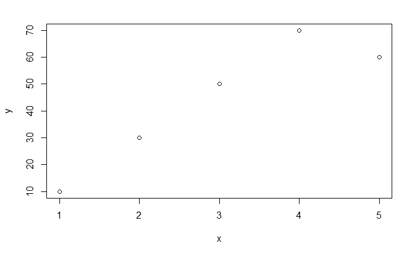

```r
x <- c(1,2,3,4,5)
y <- c(10,30,50,70,60)
plot(x,y)
```

Here, I made two vectors of numbers (x and y), and plotted them as coordinates against each other.

You will be using this `plot()` function to plot verb frequencies in the homework exercise.

# Homework exercise

For homework, I want you to try manipulating the kelly dataframe a bit more. Below are the instructions:

**Visualise frequency of verbs in the kelly data**

1. Make a new R notebook for this homework assignment, and name it “YourName-Ass1.Rmd”. Save it in your R project for this course.
2. Make a chunk of R code and load tidyverse, then read in your csv file with the Kelly data (kelly.csv or clean_kelly.csv)
3. Use `filter` to limit the Kelly tibble to verbs only
4. Use `select` to get just the verb IDs and frequency
5. Use `write_csv` to save this to a file, ‘verbs.csv’ in your ‘data’ folder in your R project. (You don’t need to upload this file to studium, just your R notebook with the code for making the csv file is fine).
6. Make a plot with verb ID as x-axis and verb frequency as y-axis
7. Upload your R Notebook in the assignments section on studium!

# Extra notes

## Variable names

Below are some principles for variable naming:

- No spaces
- Try not to use names that are also the names of functions in R
- Character a-z are okay
- Numbers are okay
- Multiword variables
  - You can separate them with _
  - Or you can use capitalisation to distinguish them
  - E.g. EngNouns, eng_nouns
- Try not to name your variables random things (e.g. a, b), but use meaningful names (e.g. nouns, verbs) – you’ll thank yourself later!